# PSTAT 231 - Homework 6

### Question 9

**Finally, set up a boosted tree model and workflow. Use the xgboost engine. Tune trees. Create a regular grid with 10 levels; let `trees` range from 10 to 2000. Specify `roc_auc` and again print an `autoplot()` of the results. What do you observe? What is the `roc_auc` of your best-performing boosted tree model on the folds?** The roc_auc value increases rapidly when the number of trees is in approximately the interval [10, 250]. The roc_auc value stays relatively the same when the number of trees is in approximately the interval [250, 2000]. In particular, the roc_auc of the best-performing boosted tree model on the folds, is 0.7166921 (obtained for number of trees is 231).

```r
btree = boost_tree(trees=tune()) %>%
  set_engine('xgboost') %>%
  set_mode('classification')
wkflow_btree = workflow() %>%
  add_model(btree) %>%
  add_recipe(recipe)
param_grid = grid_regular(trees(range=c(10, 2000)), levels=10)
```

```r
tune_grid_and_save_results(wkflow_btree, folds, param_grid,
                           metric_set(roc_auc), 'pokemon_rforest.Rds')
```

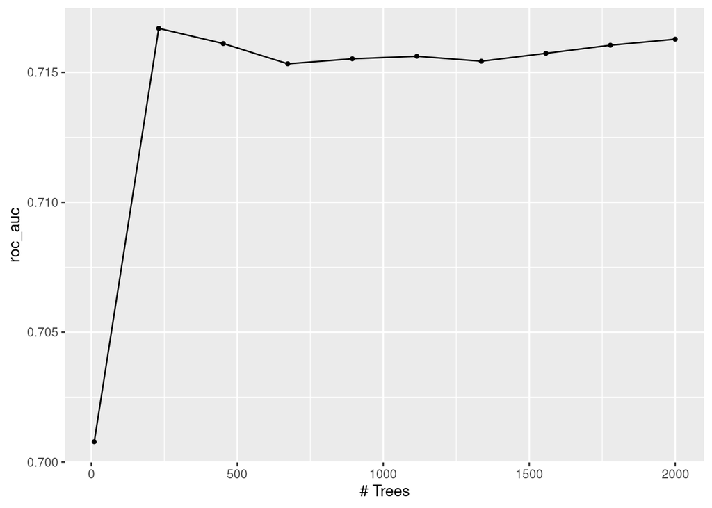

```r
tune_results_btree = readRDS('pokemon_rforest.Rds')
autoplot(tune_results_btree)
```

```r
collect_metrics(tune_results_btree) %>% arrange(desc(mean))
```

```
## # A tibble: 10 × 7
##    trees .metric .estimator  mean     n std_err .config
##    <int> <chr>   <chr>      <dbl> <int>   <dbl> <chr>
##  1   231 roc_auc hand_till  0.717     5 0.00945 Preprocessor1_Model02
##  2  2000 roc_auc hand_till  0.716     5 0.0154  Preprocessor1_Model10
##  3   452 roc_auc hand_till  0.716     5 0.0118  Preprocessor1_Model03
##  4  1778 roc_auc hand_till  0.716     5 0.0150  Preprocessor1_Model09
##  5  1557 roc_auc hand_till  0.716     5 0.0147  Preprocessor1_Model08
##  6  1115 roc_auc hand_till  0.716     5 0.0138  Preprocessor1_Model06
##  7   894 roc_auc hand_till  0.716     5 0.0132  Preprocessor1_Model05
##  8  1336 roc_auc hand_till  0.715     5 0.0145  Preprocessor1_Model07
##  9   673 roc_auc hand_till  0.715     5 0.0125  Preprocessor1_Model04
## 10    10 roc_auc hand_till  0.701     5 0.0105  Preprocessor1_Model01
```